# Exploratory Analysis on the Effect of COVID-19 on GDP

Ian Whaling 914014658, Samuel Becerra Martinez 914309570, Esmeralda Buenrostro 915430778, Ryan Truong 916857334, Team ID: 9

March 3rd, 2021

# 1 Abstract

The spread of COVID-19 had detrimental effects on economic activities following worldwide lockdowns. Our primary interest was whether there were differences among countries’ ability to recover from the initial economic impacts of COVID-19 due to overall wealth and proportion of the population with COVID-19 infections. To measure the number of infections, we used the COVID-19 dataset from the WHO Website, which granted us information about infections and deaths for various countries daily. We also looked into 2 other different datasets to explore the GDP change per quarter in 2020, along with looking into a country’s gdp per capita to gain insight about its economical standing prior to the pandemic. We decided to incorporate an analysis of variance model to explain the difference in the percentage change in GDP in fiscal quarter 3 between countries. We incorporated the population infected with COVID-19 and the GDP per capita of each nation in quarter 3 as predictors to try to account for the variance in GDP percentages. To incorporate these values into our model, we split the population infected with COVID-19 into levels relative to the number of infections and subsequently split the percentage change in GDP into levels based on the proportion of infections. We measured the statistical significance of the differences observed in percentage change in GDP and ran diagnostics to test if there were any errors in our assumptions. We also ran the non-parametric Kruskal-Wallis test to further test our assumptions across these different groups.

# 2 Introduction

COVID-19 came to shock the world socially, politically, and economically. Many governments made the decision to lockdown their countries in response to COVID-19 as a way to limit the spread of the virus. This came with direct costs to economic activities as many businesses were forced to halt their operations or adapt to regulations in order to keep productivity afloat. In this paper, we measure the impact of COVID-19 on the economy by examining the effects of COVID-related cases on nominal GDP change. We use GDP as a measurement of the economy as it tracks income and spending in the economy, and it can be compared with other countries and across time. We also note the various lockdown announcements in March of 2020 to carefully observe the changes in GDP around that time.

Our primary interest is whether there are differences across countries’ ability to recover from the initial economic impacts of COVID-19 due to the factors: proportion of the population with COVID-19 infections and relative wealth of a nation. The incentive behind this question was the lockdown and the closure of many businesses worldwide as a preventative measure to limit the spread of the virus. According to Maliszewska, Mattoo, van der Mensbrugghe (2020), the preventative actions for COVID-19 have had an immediate and significant impact on all economies. We questioned how the economy would respond in the months following the initial closure of many economic activities and whether factors like wealth and the number of positive COVID-19 results had an impact on these results. If certain countries seem to recuperate their GDP losses from the initial impacts of COVID-19 quicker than others, then the country’s overall wealth and proportion of the population with COVID-19 may have been factors.

These results may give us an indication of how economies are likely to respond to global pandemics such as COVID-19 in the future. If higher proportions of cases have larger negative impacts on the economy, then a country may consider placing even stricter restrictions on their country at the beginning of a pandemic to lessen the negative economic impacts. Similarly, if a country has a lower GDP relative to other countries, it may have difficulty recovering from the initial impacts of a pandemic which may lead to a collapse of their economy or require intervention from another country.

# 3 Background

The population that we are interested in is nations and their change in GDP. We will be attempting to model this population respective to their levels of proportion of people that are infected with COVID-19 and GDP per capita (as a measure of overall wealth).

To measure the differences across countries’ abilities to recover from the initial impacts of COVID-19, we choose to split the data into fiscal quarters, which are quarter periods that align with a regular calendar year. We decided to use quarter 3 in 2020 or Q3 to measure the recovery from the initial impacts of COVID-19 mainly seen in Q2. To keep within this time frame, we summed all the COVID-19 cases within Q3, which spans from July 1, 2020 to September 30, 2020. The variables that we chose to include are “Change_3_months” which explains the percentage change in GDP for each country. We also included “increase_cat”, which groups the countries based on the proportion of their populations infected by COVID-19. “Gdp_cat” groups countries based on their relative wealth, measured by GDP per capita.

```
## [1] "2020-01-03" "2021-03-05"
```

```
## [1] 237
```

# 4 Descriptive analysis

## 4.1 COVID-19 WHO Dataset

### 4.1.1 Countries

```
## 216 codes from your data successfully matched countries in the map
## 5 codes from your data failed to match with a country code in the map
## 27 codes from the map weren't represented in your data
```

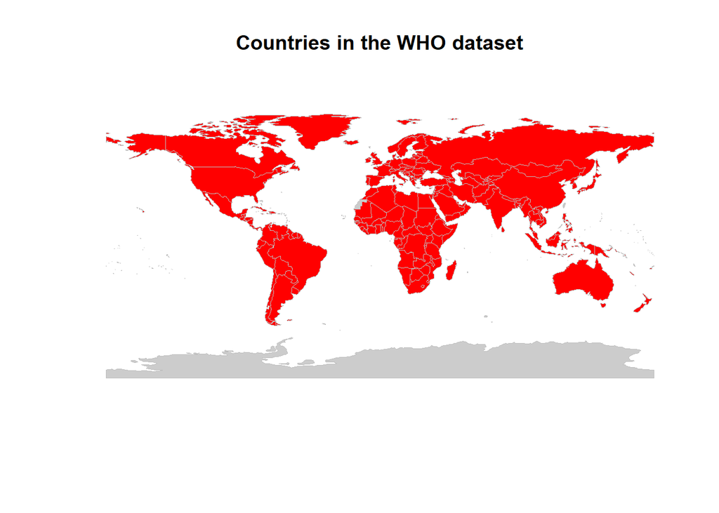

### 4.1.2 Dates

However we are only interested in the year 2020, thus the latest 2020 date is 12-31. We can see a summary statistics of the dates shown below:

```
##  Date_reported
##  Min.   :2020-01-03
##  1st Qu.:2020-04-02
##  Median :2020-07-02
##  Mean   :2020-07-02
##  3rd Qu.:2020-10-01
##  Max.   :2020-12-31
```

In our model, we decided to focus our interest not on the days but rather the quarters in the year. We manipulated the data to get the number of new cases, cumulative cases, new deaths, and cumulative death in a quarterly basis. The dates for each quarter are as follows:

- Quarter 1:
  - 2020-01-01 to 2020-03-31
- Quarter 2:
  - 2020-04-01 to 2020-06-30
- Quarter 3:
  - 2020-07-01 to 2020-09-30
- Quarter 4:
  - 2020-10-01 to 2020-12-31

### 4.1.3 Quarters

As stated in the previous section, we decided to look at the data on quarterly time frames rather by days. The summary statistics for each variable per quarter are as follows:

Where,

- starting cases = number of cases at the begining of a quarter
- ending cases = number of cases at the end of a quarter
- total cases = the number of new cases (ie. the differnce between ending and starting cases)
- … (same logic extends for ‘deaths’)

**Quarter 1:**

```
##    quarter            country          starting_cases  ending_cases
##  Length:237         Length:237         Min.   :0      Min.   :     0
##  Class :character   Class :character   1st Qu.:0      1st Qu.:     6
##  Mode  :character   Mode  :character   Median :0      Median :    69
##                                        Mean   :0      Mean   :  3341
##                                        3rd Qu.:0      3rd Qu.:   574
##                                        Max.   :0      Max.   :140640
##   total_cases     starting_deaths ending_deaths      total_deaths
##  Min.   :     0   Min.   :0       Min.   :    0.0   Min.   :    0.0
##  1st Qu.:     6   1st Qu.:0       1st Qu.:    0.0   1st Qu.:    0.0
##  Median :    69   Median :0       Median :    1.0   Median :    1.0
##  Mean   :  3341   Mean   :0       Mean   :  165.8   Mean   :  165.8
##  3rd Qu.:   574   3rd Qu.:0       3rd Qu.:    9.0   3rd Qu.:    9.0
##  Max.   :140640   Max.   :0       Max.   :11591.0   Max.   :11591.0
```

**Quarter 2:**

```
##    quarter            country          starting_cases    ending_cases
##  Length:237         Length:237         Min.   :     0   Min.   :      0
##  Class :character   Class :character   1st Qu.:     7   1st Qu.:    141
##  Mode  :character   Mode  :character   Median :    73   Median :   1568
##                                        Mean   :  3653   Mean   :  42959
##                                        3rd Qu.:   647   3rd Qu.:  13571
##                                        Max.   :163199   Max.   :2537636
##   total_cases      starting_deaths   ending_deaths     total_deaths
##  Min.   :      0   Min.   :    0.0   Min.   :     0   Min.   :     0
##  1st Qu.:     68   1st Qu.:    0.0   1st Qu.:     2   1st Qu.:     1
##  Median :   1224   Median :    1.0   Median :    28   Median :    24
##  Mean   :  39306   Mean   :  183.8   Mean   :  2118   Mean   :  1935
##  3rd Qu.:  12453   3rd Qu.:   11.0   3rd Qu.:   298   3rd Qu.:   287
##  Max.   :2374437   Max.   :12430.0   Max.   :126203   Max.   :123353
```

**Quarter 3:**

```
##    quarter            country          starting_cases     ending_cases
##  Length:237         Length:237         Min.   :      0   Min.   :      0
##  Class :character   Class :character   1st Qu.:    141   1st Qu.:    463
##  Mode  :character   Mode  :character   Median :   1594   Median :   5489
##                                        Mean   :  43611   Mean   : 143514
##                                        3rd Qu.:  13907   3rd Qu.:  51368
##                                        Max.   :2573393   Max.   :7077015
##   total_cases      starting_deaths  ending_deaths     total_deaths
##  Min.   :      0   Min.   :     0   Min.   :     0   Min.   :    0
##  1st Qu.:    175   1st Qu.:     2   1st Qu.:     8   1st Qu.:    0
##  Median :   3811   Median :    28   Median :    85   Median :   42
##  Mean   :  99903   Mean   :  2136   Mean   :  4249   Mean   : 2114
##  3rd Qu.:  32576   3rd Qu.:   302   3rd Qu.:   818   3rd Qu.:  442
##  Max.   :5640270   Max.   :126573   Max.   :203875   Max.   :83744
```

**Quarter 4:**

```
##    quarter            country          starting_cases     ending_cases
##  Length:237         Length:237         Min.   :      0   Min.   :       0
##  Class :character   Class :character   1st Qu.:    467   1st Qu.:     986
##  Mode  :character   Mode  :character   Median :   5597   Median :   13665
##                                        Mean   : 144844   Mean   :  347500
##                                        3rd Qu.:  51530   3rd Qu.:  145276
##                                        Max.   :7115491   Max.   :19346790
##   total_cases       starting_deaths  ending_deaths     total_deaths
##  Min.   :       0   Min.   :     0   Min.   :     0   Min.   :     0
##  1st Qu.:     286   1st Qu.:     8   1st Qu.:    13   1st Qu.:     1
##  Median :    5612   Median :    85   Median :   189   Median :    57
##  Mean   :  202656   Mean   :  4274   Mean   :  7605   Mean   :  3331
##  3rd Qu.:   90799   3rd Qu.:   833   3rd Qu.:  2505   3rd Qu.:  1349
##  Max.   :12231299   Max.   :204642   Max.   :335789   Max.   :131147
```

### 4.1.4 Cases

We can take a look at how the average number of new cases changes in each quarter. From the plot below, we can see that the number of average cases across all countries seem to increase from Quarter 1 of 2020 to Quarter 4:

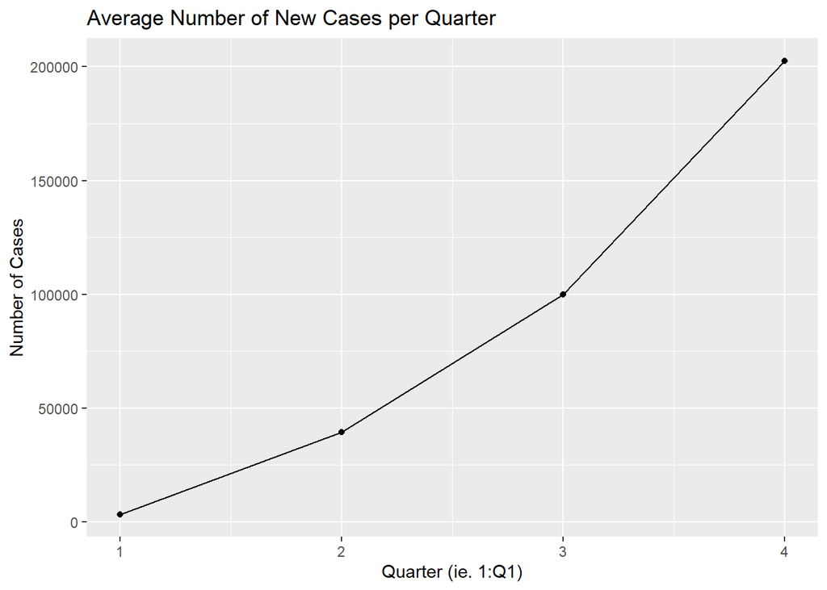

We can also plot a line graph to identify the behavior of the number of new cases per country. As we can see from the graph below, we have a one country that with a great number of new cases in quarter 4.

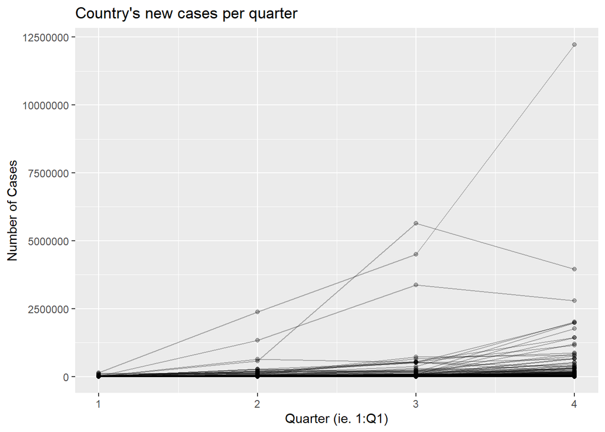

If we remove the top 3 countries we are able to zoom on the countries with less than 2,500,000 cases in quarter 4 of 2020.We can clearly see that the number of new cases in each country significantly increased from the beginning of the Pandemic (Quarter 1).

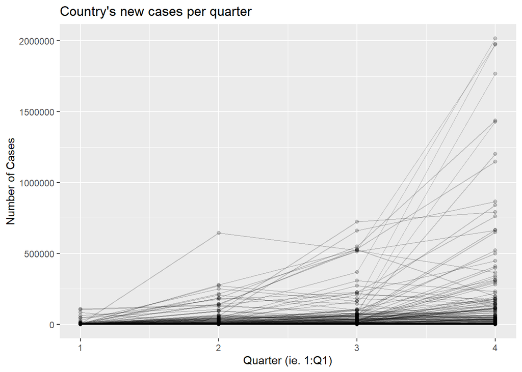

### 4.1.5 Deaths

We can take a look at how the average number of new deaths changes in each quarter. From the plot below, we can see that the number of average cases across all countries seem to increase from Quarter 1 of 2020 to Quarter 4; however from Quarter 2 to Quarter 3 we see that the rate of deaths stays constant:

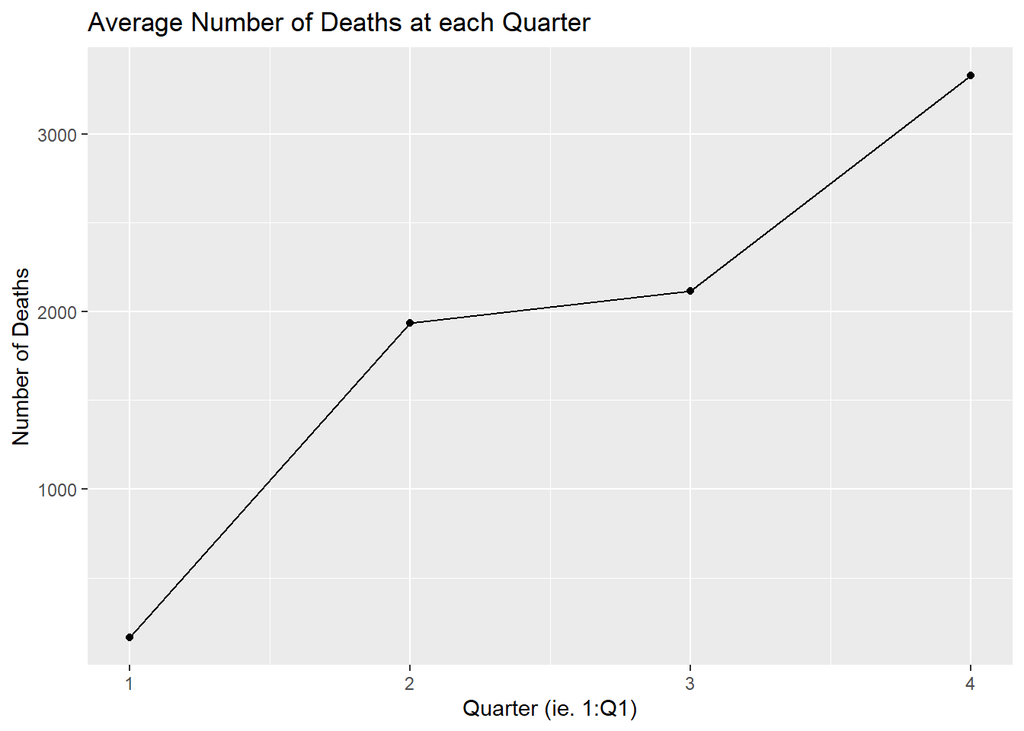

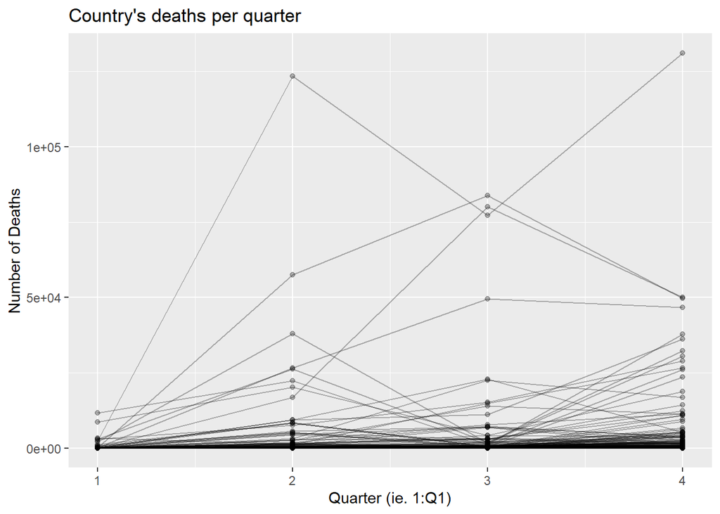

If we remove the top 4 countries we are able to zoom on the countries with less than 50,000 deaths in quarter 4 of 2020.

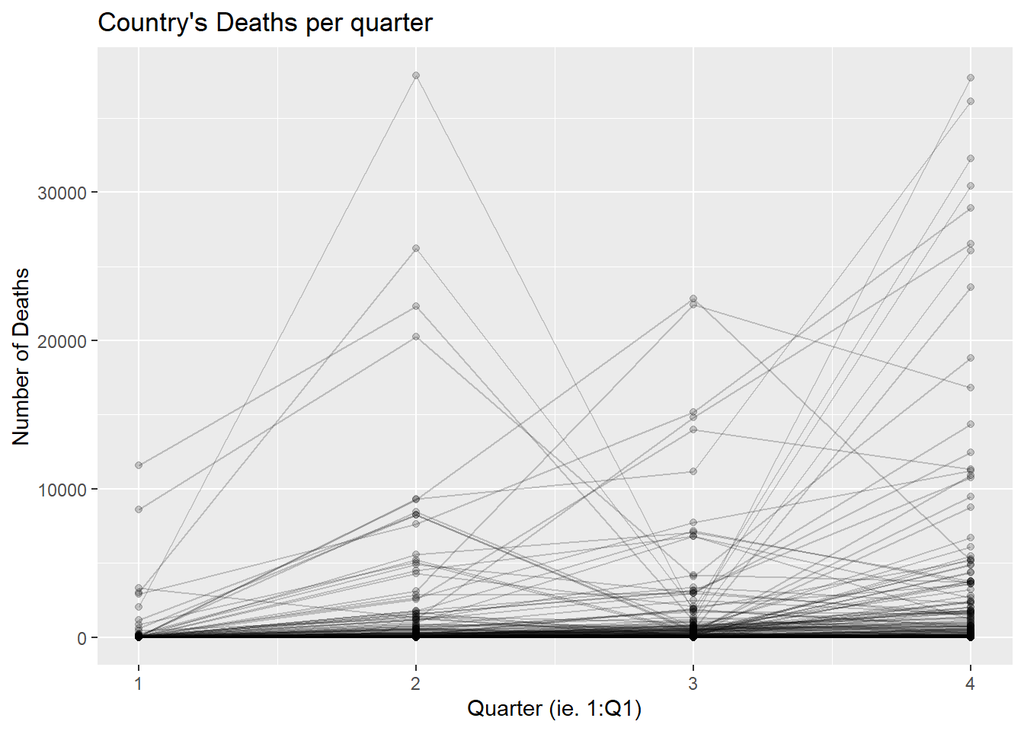

As we can see the most countries had an increase in deaths from Q1 to Q2. From Q2 to Q3 we can see that some countries resulted in a negative change while other had an increase in deaths. On average, the rate of deaths from Q2 to Q3 seems constant (see 1st graph on section 4.1.5). In quarter 4 we are able to see that most countries had an increase in deaths from Q3 to Q4. It might be hard to spot these trends from this graph, but the summary statistics from section 4.1.3 support these claims.

## 4.2 GDP Dataset

The GDP dataset we used can be found here [here](https://www.theglobaleconomy.com/rankings/gdp_current_local_currency/). This data set contains 120 observations with 5 variables:

- Countries: The name of the country
- Latest_data_from: The date of which the latest data is from
- Latest_value: GDP in billion local currency units
- Change_3_months: The change of GDP from past quarter to current
- Change_12_months: The change of GDP since last year

### 4.2.1 Countries

There is a total of 119 countries in this dataset (the remaining 1 is not a country). We can visualize which countries by observing the following map:

```
## 119 codes from your data successfully matched countries in the map
## 0 codes from your data failed to match with a country code in the map
## 124 codes from the map weren't represented in your data
```

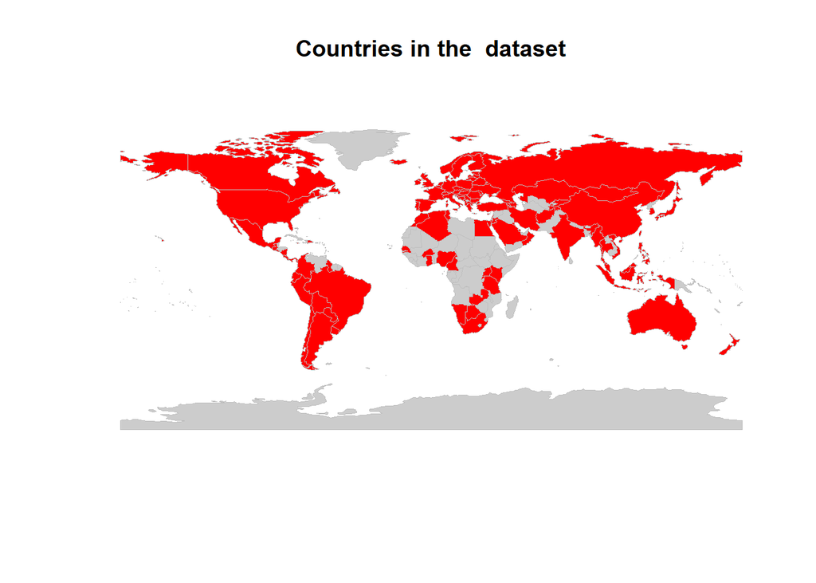

### 4.2.2 Quarters

As stated in the previous sections, we decided to look at the data on quarterly time frames. Since gdp is measured annually/quarterly, this dataset was not too difficult to find with a time frame that worked for us. Here is the distribution for the gdp information at each quarter.

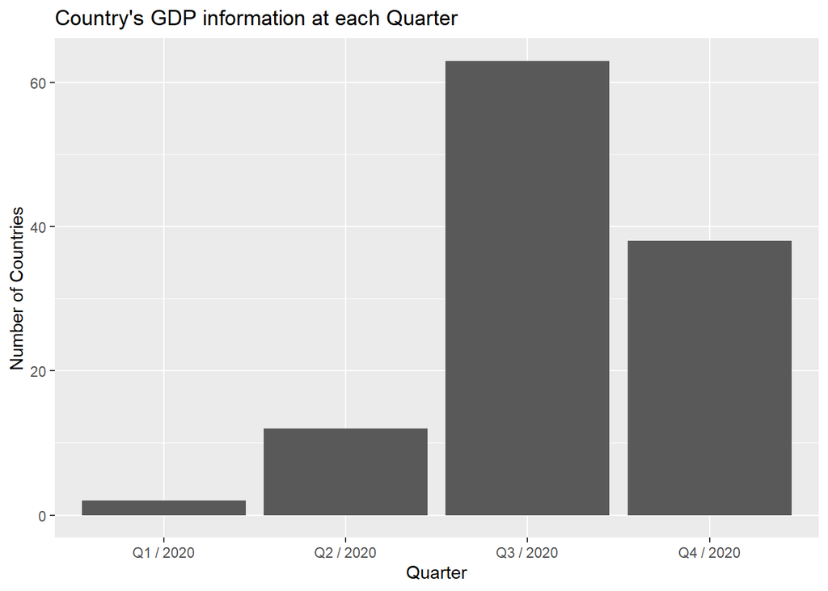

As we can see, the distribution is not uniform. There seems to be more information about a country’s GDP at Q3.

We can examine a summary statistic at each quarter; however, since the GDP is in local currency we should exclude from showing the latest value since each country is not using the same currency. Instead, lets examine the change in gdp in 3 and 12 months.

Also note that since Q1 and Q2 have low observations we should take these statistics for those quarters with caution…

**Quarter 1:**

```
##   Countries         Change_3_months   Change_12_months
##  Length:2           Min.   :-11.840   Min.   :-9.190
##  Class :character   1st Qu.:-10.367   1st Qu.:-8.207
##  Mode  :character   Median : -8.895   Median :-7.225
##                     Mean   : -8.895   Mean   :-7.225
##                     3rd Qu.: -7.423   3rd Qu.:-6.242
##                     Max.   : -5.950   Max.   :-5.260
```

**Quarter 2:**

```
##   Countries         Change_3_months   Change_12_months
##  Length:12          Min.   :-54.000   Min.   :-51.610
##  Class :character   1st Qu.:-22.735   1st Qu.:-19.720
##  Mode  :character   Median :-10.710   Median : -6.865
##                     Mean   :-16.381   Mean   :-13.678
##                     3rd Qu.: -4.353   3rd Qu.: -2.720
##                     Max.   :  4.070   Max.   :  9.700
```

**Quarter 3:**

```
##   Countries         Change_3_months  Change_12_months
##  Length:63          Min.   :-6.150   Min.   :-63.960
##  Class :character   1st Qu.: 8.045   1st Qu.: -8.640
##  Mode  :character   Median :12.030   Median : -3.390
##                     Mean   :13.636   Mean   : -3.989
##                     3rd Qu.:18.885   3rd Qu.:  0.700
##                     Max.   :47.000   Max.   : 33.190
```

**Quarter 4:**

```
##   Countries         Change_3_months  Change_12_months
##  Length:38          Min.   :-8.090   Min.   :-6.1700
##  Class :character   1st Qu.: 1.927   1st Qu.:-3.9550
##  Mode  :character   Median : 5.545   Median :-1.7400
##                     Mean   : 6.899   Mean   :-0.9363
##                     3rd Qu.: 9.232   3rd Qu.:-0.3375
##                     Max.   :39.800   Max.   :26.1900
```

## 4.3 GDP Change (3 and 12 Months)

To visualize the summary statistics lets display a boxplot for quarters 3 and 4 since those seem to have a promising number of observations.

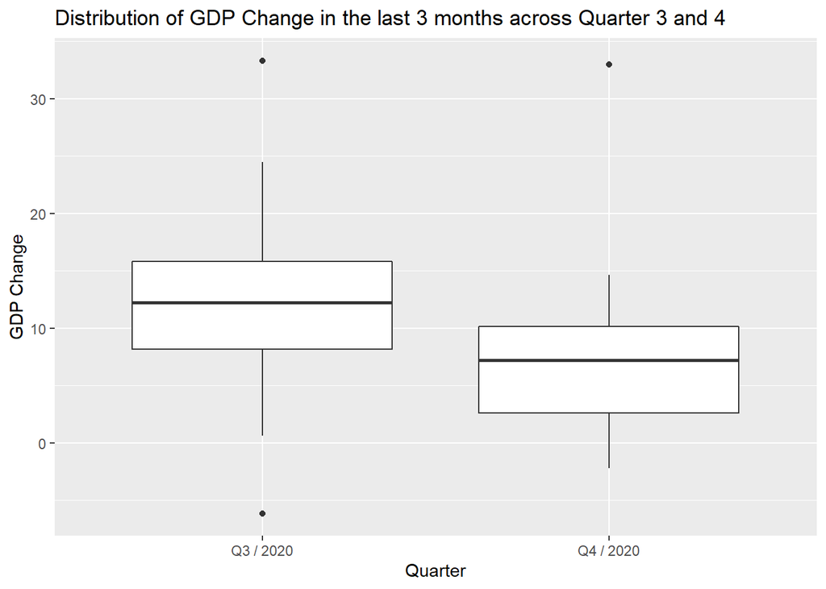

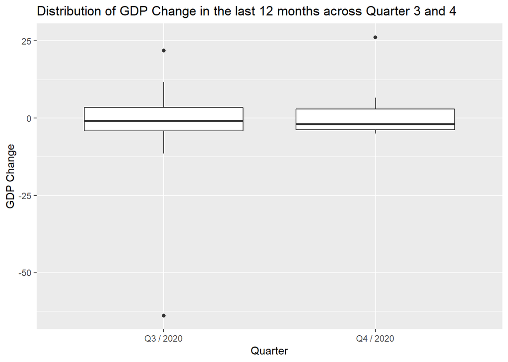

Comparing these two plots we can see that gdp change in q3 and q4 seem to have positive economical growth, whereas if we compare it to last year (12 month change) we can see that the average is slightly negative (-0.9363% change). See statistics on section 4.2.2.

## 4.4 GDP per Capita Dataset

The GDP per Capita dataset we used can be found here [here](https://www.theglobaleconomy.com/rankings/GDP_per_capita_current_dollars/). This data set contains 59 observations with 2 variables which is the country name and the GDP Per Capita (US Dollars).

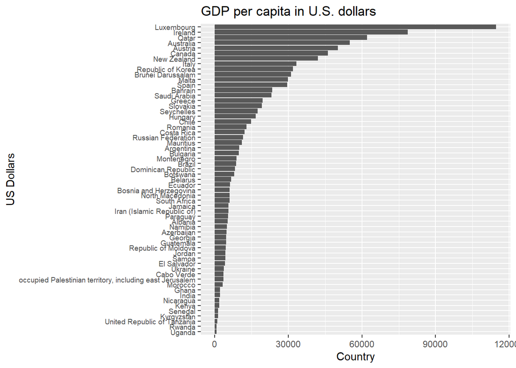

```
##    Location         GDP.per.capita
##  Length:59          Min.   :   794.3
##  Class :character   1st Qu.:  4364.8
##  Mode  :character   Median :  6663.3
##                     Mean   : 16228.2
##                     3rd Qu.: 19424.4
##                     Max.   :114704.6
```

The bar graph allows us to clearly see all the countries in the dataset along with its corresponding GDP per capita in descending order. As we can see from the summary, the average gdp per capita is about $16,228.

# 5 Inferential analysis

```
##              Df Sum Sq Mean Sq F value Pr(>F)
## increase_cat  2    385  192.49   1.748  0.184
## gdp_cat       2    151   75.46   0.685  0.508
## Residuals    54   5945  110.09
```

The ANOVA model presents F-values: 1.748 and 0.685, p-values: 0.184, 0.508 for parameters: $\alpha_{i}$ and $\beta_{j}$, respectively. With a signicance level of $\alpha = .05$ we conclude that no $\alpha_{i}$ nor any $\beta_{j}$ are shown to be signficantly signficant in the prediction of variation in the means of all countries percentage GDP change in quarter 3. We may not reject either null hypothesis: $H_0: \alpha_1 = \alpha_2 = \alpha_3 = 0$ and $H_0: \beta_1 = \beta_2 = \beta_3 = 0$, and must conclude neither proportion of the population infected with COVID-19 in quarter 3 nor GDP per capita are significant in the prediction of variation observed in percentage GDP change in quarter 3.

# 6 Model Diagnostics

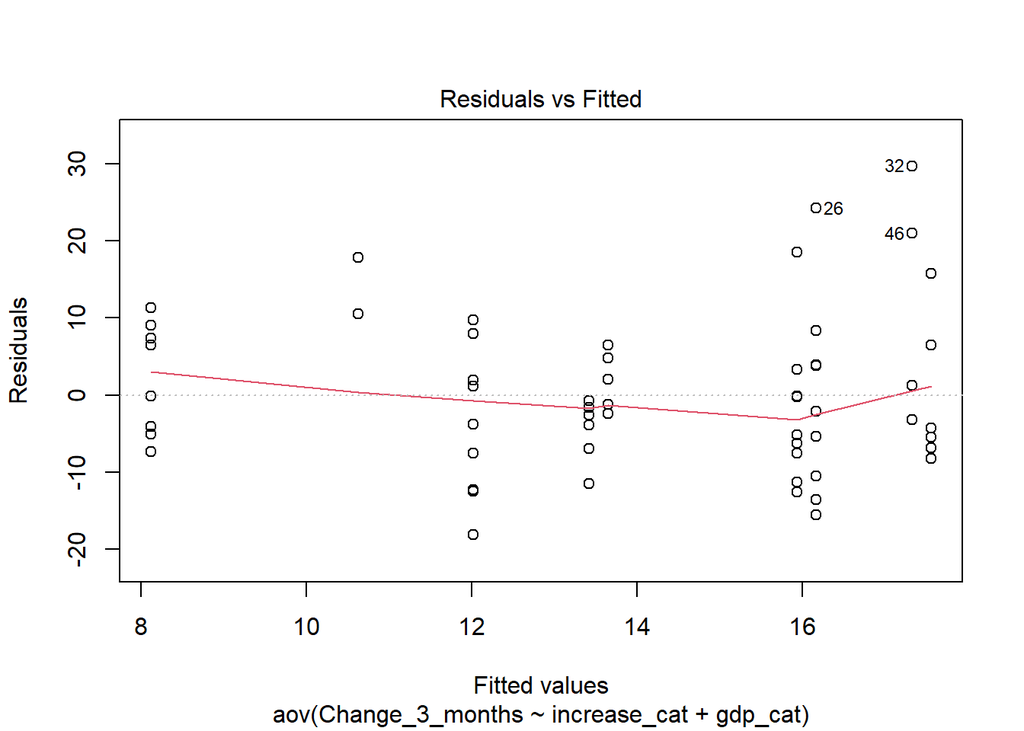

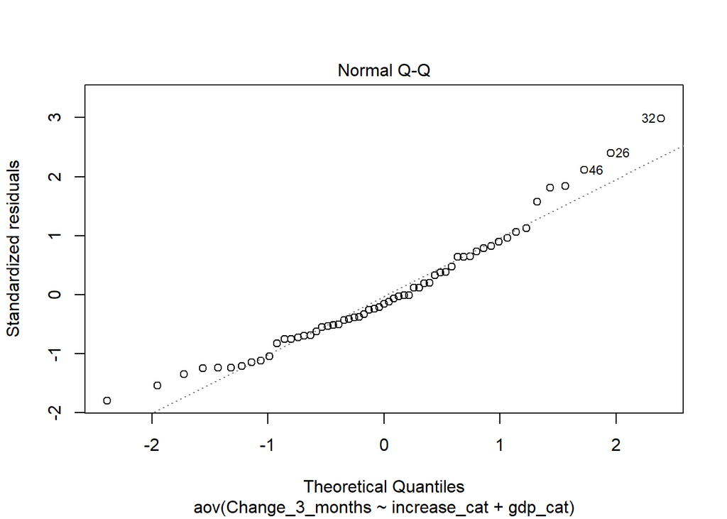

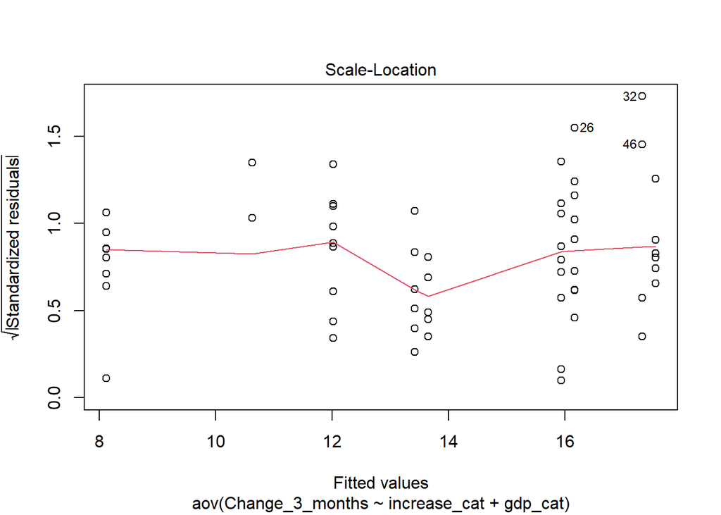

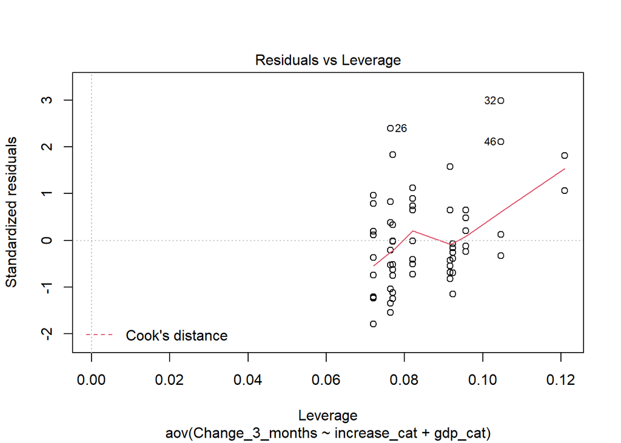

We produced diagnostic plots to determine if the assumptions of our model are correct. In our residuals vs. fitted plot we determine if there are any non-linear patterns present based on the presence of a non-horizontal pattern. Our data does not show any distinct non-horizontal pattern, so the assumption of linearity is likely fair. We next produced a Normal Q-Q plot to test the normality of our residuals, of which appear to align fairly well with the qq-line indicating our assumption of normality is fair. The Scale-Location plot we produced checks our assumption of equal variance between groups of a factor based on the horizontality of the plot, of which our data is fairly horizontal aside from a kink towards the middle. Our assumption of equal variance may be fair, but this kink in the plot gives some doubt to this assumption. The final diagnostic plot produced is the residuals vs. leverage graph which reveals any subjects that may be more influential to the data than desired, of which according to our graph there does not appear to be any.

|  | Df | F value | Pr(>F) |
| --- | --- | --- | --- |
| group | 2 | 0.1259835 | 0.8818785 |
|  | 56 | NA | NA |

|  | Df | F value | Pr(>F) |
| --- | --- | --- | --- |
| group | 2 | 2.738803 | 0.07331455 |
|  | 56 | NA | NA |

We perform a Levene’s test on each factor respective to percentage GDP change in quarter 3 for each country, and found that at p-values: .8819 ($\alpha_{i}$) and .07331 ($\beta_{j}$) we may not reject the null hypothesis of equal variance between groups for either factor at a signicance level of $\alpha = .05$.

To further explore the possibility of a signficant interaction between percentage GDP change in quarter 3 for each country and proportion of the population infected with COVID-19 in quarter 3, the more signficant factor of our ANOVA analysis, we will perform the non-parametric Kruskal-Wallis Test as an alternative to ANOVA. With this model we will not have to make the assumption of normality in our data, nor the assumption of equal variances between groups. In this model we will test the null hypothesis: $H_0: F_1(x) = F_2(x) = F_3(x)$, where $F_1(x)$ is the CDF for the group with countries with the lowest proportion of their population infected, $F_2(x)$ the CDF for the group with moderate proportion, and $F_3(x)$ the CDF for the group with the highest proportion. Our alternative hypothesis is: $H_A:$ at least one $F_{i}$ ≠ $F_{k}$ where $i = {1, 2, 3}$ and i ≠ k.

We perform 2000 permutations of Kruskal-Wallis and compare them to our observed statistic to calculate a p-value of 0.254 for our Kruskal-Wallis test, which at significance level of $\alpha = 0.05$, we may not reject the null hypothesis and must conclude that all CDFs are equivalent and there is no difference in variation of percentage GDP change in quarter 3 between each group of relative proportions of the population infected with COVID-19 in quarter 3. Given the failure of our non-parametric test to reject the null hypothesis, which does not rely on the same assumptions of the parametric ANOVA test, our conclusion that the variation observed in the percentage GDP change in quarter 3 between each country may not be explained by any group in the factor of proportions of the population infected with COVID-19 is reinforced.